# *Pristurus* ancestral reconstruction

Hector Tejero-Cicuendez

3/9/2021

## Load packages

```r
libs <- c('tidyverse', 'treeio', 'phytools', 'geiger', 'ggtree', 'rBEAST')
lapply(libs, require, character.only = TRUE)
```

## Import data

#### Import phylogeny

Import consensus tree and posterior trees

```r
tree <- read.nexus('data/phylogeny/pristurus_tree_final.nex')
posterior_pristurus <- readRDS('data/phylogeny/posterior_pristurus_final.rds')
```

#### Import morpho data

Import table with morphological and habitat data

```r
morpho <- read.table('data/morphology/morpho_sp_final.csv', sep=';', dec='.',
                               header = TRUE)
rownames(morpho) <- morpho$species

# log10-transform morpho data
morpho_log <- morpho %>%
  mutate(across(where(is.numeric), log10))
rownames(morpho_log) <- morpho_log$species
```

## Ancestral reconstruction

We will study the evolution of different traits on the phylogeny: 1) Insularity, with two different states: mainland and island. 2) habitat (broad classification), three states: rock, tree, ground. 3) habitat, four states: rock, tree, soft-ground, hard-ground.

First we fit different models of discrete character evolution: equal-rates (ER), symmetrical (SYM), and all-rates-different (ARD). Then we will reconstruct the discrete character across the phylogeny with the best-fit model. We will do it for the consensus tree and then for 100 trees from the posterior. We will do 1,000 simulations for the consensus ancestral reconstruction, and 100 simulations for the posterior trees.

```r
ntrees <- 100
nsim <- 100
```

#### 1) Insularity ancestral reconstruction

```r
# Set colors and create trait variable
land_colors <- c(mainland = 'coral2', island = 'seagreen')
land <- morpho$land
names(land) <- row.names(morpho)
```

```r
# Fit models of discrete character evolution
fit_ER_land <- fitDiscrete(tree, land, model = 'ER')
fit_SYM_land <- fitDiscrete(tree, land, model = 'SYM')
fit_ARD_land <- fitDiscrete(tree, land, model = 'ARD')
aicw(c(fit_ER_land$opt$aicc, fit_SYM_land$opt$aicc,
       fit_ARD_land$opt$aicc))

# Best fit model for land: ER

# Make simmap with consensus tree
simmap_land <- make.simmap(tree = tree, x = land, model = 'ER', nsim = 1000)
plotSimmap(simmap_land, colors = land_colors)
pd_land <- describe.simmap(simmap_land, plot=FALSE)

# Save simmap object
saveRDS(pd_land, 'objects/anc_rec/pd_land_cons.rds')
```

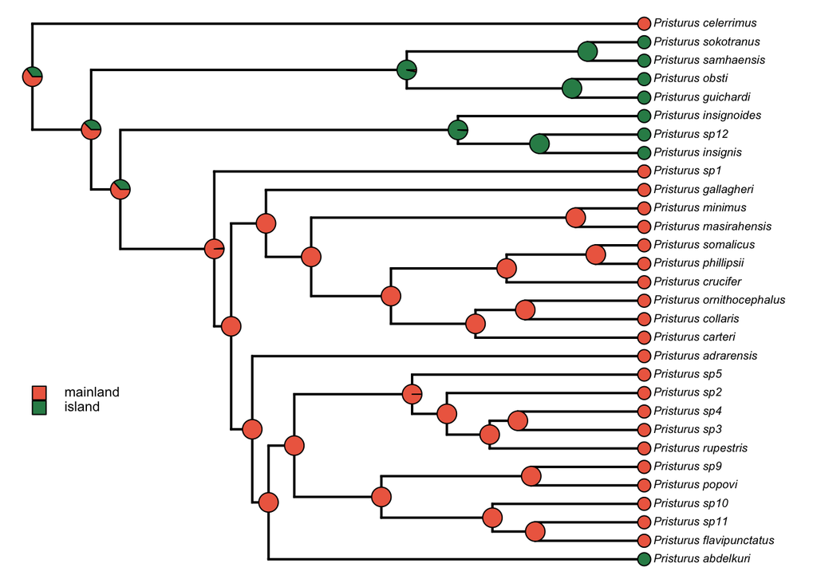

```r
pd_land <- readRDS("objects/anc_rec/pd_land_cons.rds")

# Plot reconstruction
plot(pd_land, fsize=0.6, ftype="i", colors = land_colors)
add.simmap.legend(colors=land_colors, prompt=FALSE, fsize=0.7, x = 0, y = 10)
```

```r
# Make simmap with posterior trees
#sampling_trees <- sample(1:length(posterior_pristurus), size = ntrees, replace = FALSE)
simmap_land_post <- make.simmap(tree = posterior_pristurus[1:ntrees],
                                         x = land, model = 'ER', nsim = nsim)

plotSimmap(simmap_land_post, colors = land_colors)
pd_land_post <- list()
n <- 1
m <- nsim
for (i in 1:ntrees){
  print(paste(n, m, sep = ' to '))
  pd_land_post[[i]] <-  describe.simmap(simmap_land_post[n:m], plot=FALSE)
  n <- n+nsim
  m <- m+nsim
}
plot(pd_land_post[[i]])

# pd_land_post is a list with ntrees simmap summaries of nsim simulations each.
saveRDS(pd_land_post, 'objects/anc_rec/pd_land_post.rds')
```

#### 2) Habitat broad ancestral reconstruction

```r
# Set colors and create trait variable
habitat_broad_colors <- c(ground = 'brown', rock = 'gray', tree = 'darkgreen')
habitat_broad <- morpho$habitat_broad
names(habitat_broad) <- row.names(morpho)
```

```r
# Fit models of discrete character evolution
fit_ER_habitat_broad <- fitDiscrete(tree, habitat_broad, model = 'ER')
fit_SYM_habitat_broad <- fitDiscrete(tree, habitat_broad, model = 'SYM')
fit_ARD_habitat_broad <- fitDiscrete(tree, habitat_broad, model = 'ARD')
aicw(c(fit_ER_habitat_broad$opt$aicc, fit_SYM_habitat_broad$opt$aicc,
       fit_ARD_habitat_broad$opt$aicc))
# Best fit model for habitat broad: ER

# Make simmap with consensus tree
simmap_habitat_broad <- make.simmap(tree = tree, x = habitat_broad, model = 'ER', nsim = 1000)
plotSimmap(simmap_habitat_broad, colors = habitat_broad_colors)
pd_habitat_broad <- describe.simmap(simmap_habitat_broad, plot=FALSE)

# Save simmap object
saveRDS(pd_habitat_broad, 'objects/anc_rec/pd_habitat_broad_cons.rds')
```

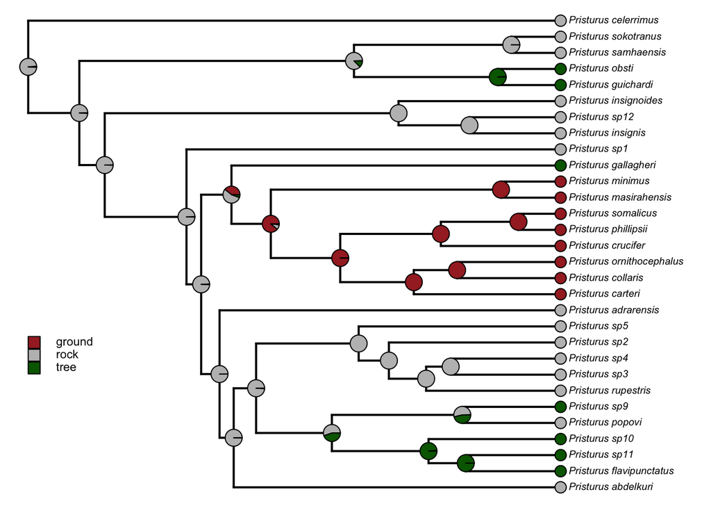

```r
pd_habitat_broad <- readRDS("objects/anc_rec/pd_habitat_broad_cons.rds")

# Plot reconstruction
plot(pd_habitat_broad, fsize=0.6, ftype="i", colors = habitat_broad_colors)
add.simmap.legend(colors=habitat_broad_colors, prompt=FALSE, fsize=0.7, x = 0, y = 10)
```

```r
# Make simmap with posterior trees
#sampling_trees <- sample(1:length(posterior_pristurus), size = ntrees, replace = FALSE)
simmap_habitat_broad_post <- make.simmap(tree = posterior_pristurus[1:ntrees],
                                         x = habitat_broad, model = 'ER', nsim = nsim)

plotSimmap(simmap_habitat_broad_post, colors = habitat_broad_colors)
pd_habitat_broad_post <- list()
n <- 1
m <- nsim
for (i in 1:ntrees){
  print(paste(n, m, sep = ' to '))
  pd_habitat_broad_post[[i]] <-  describe.simmap(simmap_habitat_broad_post[n:m], plot=FALSE)
  n <- n+nsim
  m <- m+nsim
}
plot(pd_habitat_broad_post[[i]])
# pd_habitat_broad_post is a list with ntrees simmap summaries of nsim simulations each.

saveRDS(pd_habitat_broad_post, 'objects/anc_rec/pd_habitat_broad_post.rds')
```

#### 3) Habitat ancestral reconstruction

```r
# Set colors and create trait variable
habitat_colors <- c('hard-ground' = 'brown', 'soft-ground' = 'orange',
                    rock = 'gray', tree = 'darkgreen')
habitat <- morpho$habitat
names(habitat) <- row.names(morpho)
```

```r
# Fit models of discrete character evolution
fit_ER_habitat <- fitDiscrete(tree, habitat, model = 'ER')
fit_SYM_habitat <- fitDiscrete(tree, habitat, model = 'SYM')
fit_ARD_habitat <- fitDiscrete(tree, habitat, model = 'ARD')
aicw(c(fit_ER_habitat$opt$aicc, fit_SYM_habitat$opt$aicc,
       fit_ARD_habitat$opt$aicc))
# Best fit model for habitat: ER

# Make simmap with consensus tree
simmap_habitat <- make.simmap(tree = tree, x = habitat, model = 'ER', nsim = 1000)
plotSimmap(simmap_habitat, colors = habitat_colors)
pd_habitat <- describe.simmap(simmap_habitat, plot=FALSE)

# Save simmap object
saveRDS(pd_habitat, 'objects/anc_rec/pd_habitat_cons.rds')
```

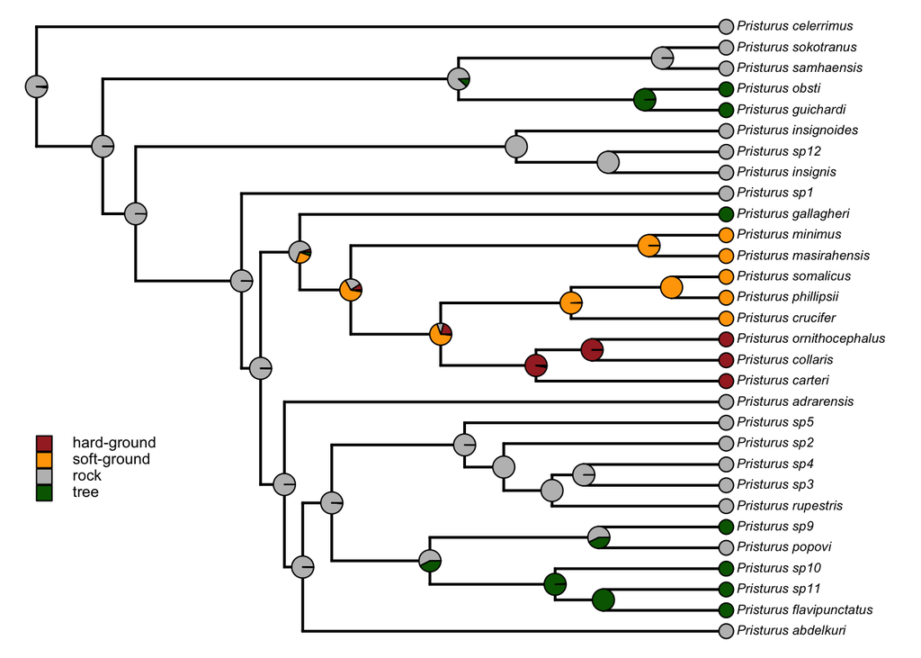

```r
pd_habitat <- readRDS("objects/anc_rec/pd_habitat_cons.rds")

# Plot reconstruction
plot(pd_habitat, fsize=0.6, ftype="i", colors = habitat_colors)
add.simmap.legend(colors=habitat_colors, prompt=FALSE, fsize=0.7, x = 0, y = 10)
```

```r
# Make simmap with posterior trees
#sampling_trees <- sample(1:length(posterior_pristurus), size = ntrees, replace = FALSE)
nsim <- 100
ntrees <- 100
#sampling_trees <- sample(1:length(posterior_pristurus), size = ntrees, replace = FALSE)
simmap_habitat_post <- make.simmap(tree = posterior_pristurus[1:ntrees],
                                         x = habitat, model = 'ER', nsim = nsim)

plotSimmap(simmap_habitat_post, colors = habitat_colors)
pd_habitat_post <- list()
n <- 1
m <- nsim
for (i in 1:ntrees){
  print(paste(n, m, sep = ' to '))
  pd_habitat_post[[i]] <-  describe.simmap(simmap_habitat_post[n:m], plot=FALSE)
  n <- n+nsim
  m <- m+nsim
}
plot(pd_habitat_post[[i]])
# pd_habitat_post is a list with ntrees simmap summaries of nsim simulations each.

saveRDS(pd_habitat_post, 'objects/anc_rec/pd_habitat_post.rds')
```

## Conclusion

Now we have the *Pristurus* phylogeny (and the posterior trees) mapped with the discrete traits. We will use them for subsequent analyses of evolutionary rates of continuous variables (size and shape), exploring how the insularity or the habitat specialization have affected morphological evolution in this genus.